# *REGEL - AB Testing with the Ratio of the Expected Gain to the Expected Loss*

# [Aaron McDaid](https://aaronmcdaid.github.io/)

Statistics and Python and C++, and other fun projects

`aaron.mcdaid@gmail.com`

[`@aaronmcdaid`](https://twitter.com/aaronmcdaid)

*by [Aaron](https://aaronmcdaid.github.io/), 2nd January 2019*

(code for this document)

In this post I propose a simple method for AB Testing, using Bayesian ideas. But my evaluation is frequentist, as I discuss the Type I error rate. And even though there are a lot of complex simulations in this post, the method itself is quite simple and efficient - it uses only the information that is required to perform a t-test.

*I think this is a new method, but please tell me if you recognize anything! Fundamentally, my motivation here is personal curiousity; to play with some new ideas and some new software. If I have also accidentally stumbled upon something useful, then that’s nice too!*

(There is a [library associated with this post on Github](https://github.com/aaronmcdaid/bayesian.risk), where I also include the Jupyter notebook with which I developed and tested this model.)

The basic idea is to answer these two questions:

- **Stopping Criterion**: When do we stop the experiment?
- **Decision Criterion**: And, once stopped, how do we choose between these three possible decisions?
  1. *Positive* - variant B is better.
  2. *Neutral* - unclear which variant is better.
  3. *Negative* - variant A is better.

If the effect is strong, we want a stopping criterion which will stop early.

## (very simple overview/summary)

Given any stopping criterion and decision criterion (Bayesian or otherwise), we must answer a few basic questions. If there is truly no effect, i.e. truly no difference in the performance of variant A and variant B, then how will our criteria behave? What will be the average runtime of an experiment under this condition? What will be the maximum runtime? What decisions will be made?

We can investigate this with simulations. We run many simulations, where there truly is zero difference in performance. We can record the average runtime - i.e. record the sample size at which the Stopping Criterion is achieved. And we can record what decisions are reached then. In this case, the *Neutral* decision is the correct decision, and therefore we hope that the majority of simulations result in the *Neutral* decision.

On the other hand, if there truly is a difference in performance, we hope that most simulations will result in the correct decision, where the correct decision is either *Positive* or *Negative*. In the case of a strong effect, we have a strong preference to have short runtimes also.

A very simple method is to simply compute the *expected loss* and *expected gain* (defined below) constantly throughout your experiment. At least one of those is guaranteed to tend to zero, hence you can reasonably say that your Stopping Criterion is:

> We stop the experiment when either of those quantities is within $\tau$ of zero. i.e. when $\min(x,y) < \tau$

## Student’s t-test

To begin, let’s recap the [t-test](https://en.wikipedia.org/wiki/Student%27s_t-test#Equal_or_unequal_sample_sizes,_equal_variance). We have a sample from each of the two group, with estimates of the mean in each group, $\hat\mu_A$ and $\hat\mu_B$. We also have [estimates](https://en.wikipedia.org/wiki/Bessel%27s_correction) of the variance in each group, $\hat\sigma^2_A$ and $\hat\sigma^2_B$.

The *pooled variance estimate* is a weighted combination of the two variance estimates:

$$\hat\sigma_{pooled} = \frac{(n_A-1)\hat\sigma^2_A + (n_B-1)\hat\sigma^2_B}{n_A+n_B-2}$$
The variance of the estimator of the mean tells us how close the estimated mean is to the true mean:

$$\mathrm{Var}(\hat\mu_A) = \frac1{n_A} \hat\sigma_{pooled}$$

$$\mathrm{Var}(\hat\mu_B) = \frac1{n_B} \hat\sigma_{pooled}$$

The variance of a sum (or difference) is the sum of the variances. Therefore, if we estimate the difference in the means as

$${\hat\Delta}= (\hat\mu_B - \hat\mu_A)$$

then the variance of the estimator ${\hat\Delta}$ is
$$\begin{aligned}
{\operatorname{Var}[{\hat\Delta}]}& = \mathrm{Var}(\hat\mu_B - \hat\mu_A) \\
& = \mathrm{Var}(\hat\mu_A) + \mathrm{Var}(\hat\mu_B) \\
& = \frac1{n_A}\hat\sigma^2_{pooled}
+\frac1{n_B}\hat\sigma^2_{pooled}
\end{aligned}$$

Now, we have the estimate of the effect, ${\hat\Delta}$, and the variance of that estimate, ${\operatorname{Var}[{\hat\Delta}]}$, and we could proceed to compute a p-value. However, in this post I’ll take a different approach.

## Normality, and the posterior

I’m going to assume the likelihood function is [normal](https://en.wikipedia.org/wiki/Gaussian_distribution). This will be an important assumption later in this post when I discuss sufficient statistics. But it really just means that I’m assuming the sample size is reasonably large. If you want to use just a few dozen samples, then this method isn’t for you!

I’m just using a flat prior here. The prior doesn’t matter if you have a large sample size. I *do* find other priors really interesting, and I really enjoyed writing this blog post about *unit information priors*! But it doesn’t matter for large sample sizes.

Therefore, the posterior distribution used in this method is a normal distribution:

$$\Delta|\cdot \sim \mathcal{N}({\hat\Delta}, {\operatorname{Var}[{\hat\Delta}]})$$

## Expected Loss and Expected Gain

The posterior is interpreted as an estimate of the effect, and the uncertainty of that effect. Imagine drawing numbers randomly from the posterior, then replacing the positive numbers with zero, and then compute the mean of this distribution. This is the [*expected loss*](https://medium.com/convoy-tech/the-power-of-bayesian-a-b-testing-f859d2219d5) of variant B.

$$EL = \mathbb{E}\mathopen{}\left[\operatorname{min}\left(0, \mathcal{N}\mathopen{}\left({\hat\Delta}, {\operatorname{Var}[{\hat\Delta}]}\right)\mathclose{}\right)\right]\mathclose{}$$

In the [library associated with this post](https://github.com/aaronmcdaid/bayesian.risk/blob/master/bayesianAB/risk.py) includes python code for computing this, named [`slow_risk`](https://github.com/aaronmcdaid/bayesian.risk/blob/master/bayesianAB/risk.py#L18). In that library, I use the term *risk* as shorthand for *expected loss*.

I define *expected gain* as the opposite, i.e. the result when replacing negative values with zero.

$$EG = \mathbb{E}\mathopen{}\left[\operatorname{max}\left(0, \mathcal{N}\mathopen{}\left({\hat\Delta}, {\operatorname{Var}[{\hat\Delta}]}\right)\mathclose{}\right)\right]\mathclose{}$$

## Why compute the EL and EG?

As we run the experiment, we compute both EL and EG as often as we like. Perhaps after every data point, or perhaps every hour. If there truly is no difference between the performance of A and the performance of B, then both EL and EG will gradually approach zero. They will never reach exactly zero. In fact, EL will always be negative, and EG will always be positive. But they will each become arbitrarily to zero if you keeping running the experiment. For the remainder of this post, I will usually use $(-EL)$ in the formulae as it will always be positive and is easier to reason about.

If B is better, i.e. the true effect $\Delta_0 > 0$, then EL will tend to zero and EG will tend to $\Delta_0$. Formally, we can say that as the number of samples $n$ tends to infinity,

$$\lim_{n\rightarrow\infty} EL = \min(0, \Delta_0) \\$$
$$\lim_{n\rightarrow\infty} EG = \max(0, \Delta_0) \\$$

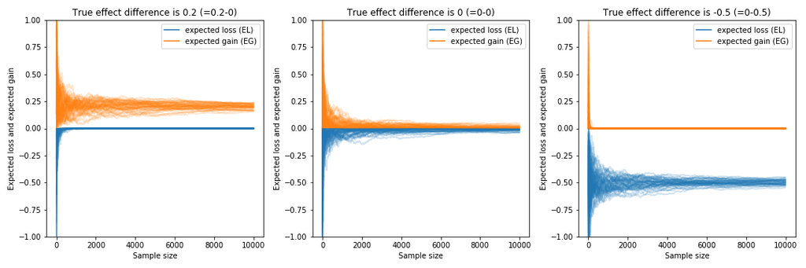

*Figure 1*: Trend of EL and EG as samples are gathered. 50 simulations were run under each of three conditions.

## When to stop?

One simple approach, discussed [here](https://medium.com/convoy-tech/the-power-of-bayesian-a-b-testing-f859d2219d5), is to end the experiment when either EL or EG become sufficiently close to zero, as defined by a user-defined *threshold-of-caring*, $\tau$.

$$\min(-EL, EG) < \tau$$

While it certainly is a simple approach, it has the disadvantage that the *runtime*, i.e. the number of samples needed to reach this stopping condition, has a huge variance. Sometimes it can take a very long time to reach this stopping condition - and it’s likely that you will be tempted to simply end the experiment early in that case. We see this in the next figure, where 1000 simulations were performed under the null hypothesis and then the runtimes were sorted and plotted in blue. I normalized the data such that the average runtime is 5,000 samples. As you can see in the top right of *Figure 2*, this simple policy took 60,000 samples to reach this simple stopping condition under one of the simulations. For comparison, two other stopping conditions are included.

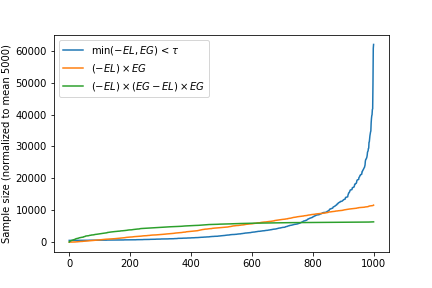

*Figure 2*: Three different stopping criteria are shown here. 1000 simulations under the null are run until the criterion is reached, and then the runtimes (numbers of samples) are sorted and plotted.

The second approach uses the product, instead of the minimum, of the EL and the EG and stops the experiment when the product, $(-EL) \times EG$ comes below a predefined threshold. As can be seen above, the maximum runtime is much smaller.

The method I present in this paper, which I call *REGEL* (Ratio of Expected Gain and Expected Loss), uses the product of three factors. This is the *REGEL* stopping condition (I’ll discuss the threshold later):
$$(-EL) \times (EG{+}(-EL)) \times EG \qquad < \qquad ???$$

Of course, if our goal is to simply minimize the maximum runtime, we could just insert a hard upper bound on the sample size. However, for a variety of reasons, I want a stopping criterion and decision criterion based strictly on EL and EG and on nothing else.

## Decision time: Negative, Neutral, or Positive?

Once the stopping condition has been reached and the experiment has been stopped, we still have to decide on the outcome. Which variant, if any, is better? This is done using the ratio of EG to the EL. If the ratio is very large or very small, we have a Positive or Negative decision. Otherwise, we have a Neutral decision. For this blog post, I use a ratio of 350. In other words, after the experiment has stopped:

- **Positive** , i.e. variant B is better, if $EG > 350 \times (-EL)$
- **Negative** , i.e. variant A is better, if $EG < \frac1{350} \times (-EL)$
- **Neutral** , otherwise

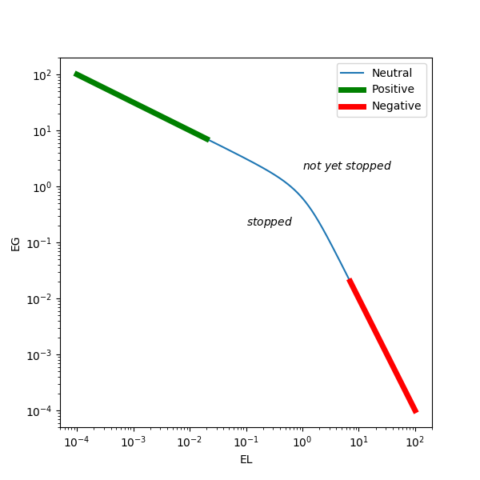

*Figure 3*: The curve is the range of (EL,EG) pairs for which the stopping criterion is reached, $(-EL)(EG-EL)EG < 1$. The colour tells us which decision is taken.

## Why 350?

You might ask why I use a ratio of 350 as the decision ratio in the decision criterion. That’s the first “magic number” in this blog post. The reason is that it gives a [Type I error rate](https://en.wikipedia.org/wiki/Type_I_and_type_II_errors#Type_I_error) of 10%. In other words, if the null hypothesis is true (i.e. there is truly no difference between between the two variants) and we run an experiment until the REGEL stopping criterion is reached, approximately 10% of the simulation will result in a non-Neutral decision. 5% will be Positive and 5% will be Negative.

I discovered this via extensive simulations. Bear in mind that stopping criteria with a different form - i.e. something other than $(-EL)(EG-EL)(EG) < ???$ - will result in a different relationship between the decision ratio and the Type I error rate. You might be skeptical and wonder how transferable this is. Different simulations with different parameters might lead to different results? Actually no, this ratio always gives a Type I error rate of approximately 10% when combined with the REGEL stopping criterion, not matter what threshold is used within the stopping criterion (see Figure 4). This also holds if we vary other simulation parameters. The only requirement is that the threshold be small enough to require at least a few hundred samples, as a large sample size will ensure the normality assumptions hold.

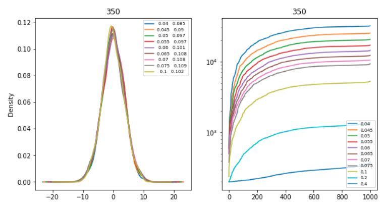

I also experimented with many other simulations to verify the robustness of this. For example, I considered a 10%/90% split between the two variants instead of the usual 50%/50% split. But to really prove that this is a general result, some mathematical proof is required. So I’ll attempt to do so here

(Next couple of paragraphs are quite technical. Although, I think I would like to make them even more technical! Maybe you can help me to firm this up.)

As described at the start of this post, we assume the likelihood and the posterior are normally distributed. This is reasonable given a large enough sample size, and also given that the model is about the difference of two sample means. In other words, the [Central Limit Theorem](https://en.wikipedia.org/wiki/Central_Limit_Theorem) applies.

This assumption allows us to treat the mean and variance as [*sufficient statistics*](https://en.wikipedia.org/wiki/sufficient_statistic) to describe the distribution. The EL and EG are functions of the mean and variance; and also, we can compute the mean and variance from the EL and EG. This allows us to say that the EL and EG are sufficient statistics for the posterior distribution.

This is useful because it means that two different experiments that have the same EL and also have the same EG can be said to be in the same “state”, and the future behaviour of the EL and EG (as new data is observed) is the same in both.

Another issue is *scale invariance*. If the EL and EG are computed in units of centimetres, and then we convert them to units of inches, then the numbers are scaled but the experiment is fundamentally the same. This observation, combined with the sufficient argument, allow us to see why there is consistency in the left panel of Figure 4.

Thanks for making it this far! I’d love feedback, see my Twitter handle and my email address at the top of the page.

*by [Aaron](https://aaronmcdaid.github.io/), 2nd January 2019*